# Predicting Exercise Quality

Yuemin

2025-06-12

## Introduction

This project aims to predict the quality of exercise performance (the “classe” variable) using accelerometer data from devices on the belt, forearm, arm, and dumbbell of six participants. The “classe” variable in the training dataset (pml-training.csv) indicates whether an exercise was performed correctly or with specific errors. The report details the model-building process, cross-validation, expected out-of-sample error, and predictions for 20 test cases from pml-testing.csv. The goal is to create an accurate model while justifying methodological choices.

```r
# Install required packages
if (!require(httr)) install.packages("httr")
if (!require(caret)) install.packages("caret")
if (!require(randomForest)) install.packages("randomForest")
library(httr)
library(caret)
library(randomForest)

# load data
setwd("~/Desktop")
training <- read.csv("training.csv")
testing <- read.csv("testing.csv")
```

## Preprocessing

The training dataset has many columns with missing values and non-predictive variables (e.g., timestamps, user names). We remove columns with over 90% missing values and non-predictive variables, then eliminate near-zero-variance predictors to reduce noise.

```r
# Convert classe to factor
training$classe <- as.factor(training$classe)

# Remove columns with >90% NAs
na_cols <- colSums(is.na(training)) / nrow(training) > 0.9
training <- training[, !na_cols]
testing <- testing[, !na_cols]

# Remove non-predictive columns (first 7: X, user_name, timestamps, etc.)
training <- training[, -(1:7)]
testing <- testing[, -(1:7)]

# Remove near-zero-variance predictors
nzv <- nearZeroVar(training, saveMetrics = TRUE)
training <- training[, !nzv$nzv]
testing <- testing[, names(training)[names(training) != "classe"]]

# Final dimensions
dim(training)
```

```
## [1] 19622    53
```

```r
dim(testing)
```

```
## [1] 20 52
```

## Exploratory Data Analysis

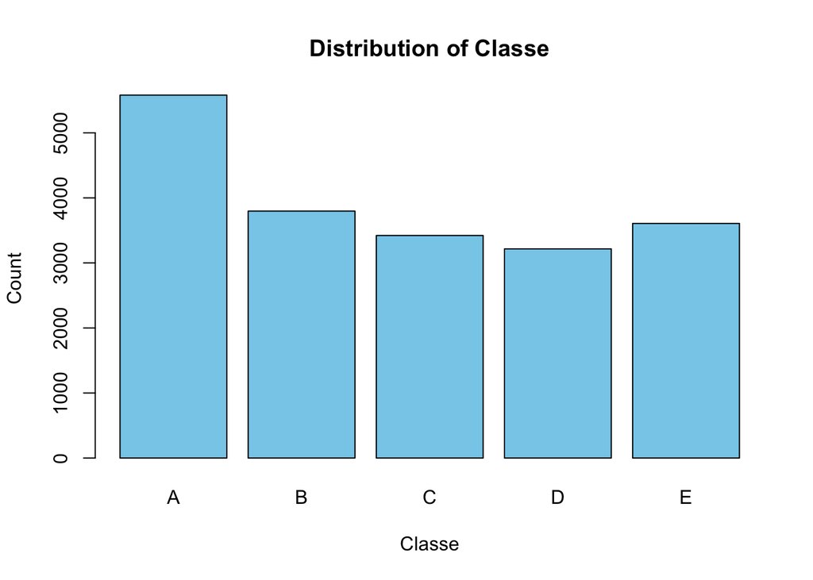

```r
barplot(table(training$classe), main="Distribution of Classe", xlab="Classe", ylab="Count", col="skyblue")
```

## Model Building Choices

I use a random forest model because: 1. It handles high-dimensional, non-linear data well. 2. It’s robust to noise and provides feature importance. 3. It reduces overfitting via bagging.

## Cross-Validation and Model Training

I use 5-fold cross-validation and split the data into 80% training and 20% validation sets.

```r
# Set seed
set.seed(123)

# Split data
trainIndex <- createDataPartition(training$classe, p=0.8, list=FALSE)
trainData <- training[trainIndex, ]
validData <- training[-trainIndex, ]

# Ensure classe is factor
trainData$classe <- as.factor(trainData$classe)
validData$classe <- factor(validData$classe, levels = levels(trainData$classe))

# Train random forest
rf_model <- train(classe ~ .,
                  data = trainData,
                  method = "rf",
                  trControl = trainControl(method = "cv", number = 5),
                  tuneGrid = data.frame(mtry = floor(sqrt(ncol(trainData)-1))))
```

## Model Performance and Out-of-Sample Error

```r
# Predict on validation set
valid_pred <- predict(rf_model, validData)

# Confusion matrix
conf_matrix <- confusionMatrix(valid_pred, validData$classe)
print(conf_matrix)
```

```
## Confusion Matrix and Statistics
##
##           Reference
## Prediction    A    B    C    D    E
##          A 1116    4    0    0    0
##          B    0  755    3    0    0
##          C    0    0  681    4    0
##          D    0    0    0  639    6
##          E    0    0    0    0  715
##
## Overall Statistics
##
##                Accuracy : 0.9957
##                  95% CI : (0.9931, 0.9975)
##     No Information Rate : 0.2845
##     P-Value [Acc > NIR] : < 2.2e-16
##
##                   Kappa : 0.9945
##
##  Mcnemar's Test P-Value : NA
##
## Statistics by Class:
##
##                      Class: A Class: B Class: C Class: D Class: E
## Sensitivity            1.0000   0.9947   0.9956   0.9938   0.9917
## Specificity            0.9986   0.9991   0.9988   0.9982   1.0000
## Pos Pred Value         0.9964   0.9960   0.9942   0.9907   1.0000
## Neg Pred Value         1.0000   0.9987   0.9991   0.9988   0.9981
## Prevalence             0.2845   0.1935   0.1744   0.1639   0.1838
## Detection Rate         0.2845   0.1925   0.1736   0.1629   0.1823
## Detection Prevalence   0.2855   0.1932   0.1746   0.1644   0.1823
## Balanced Accuracy      0.9993   0.9969   0.9972   0.9960   0.9958
```

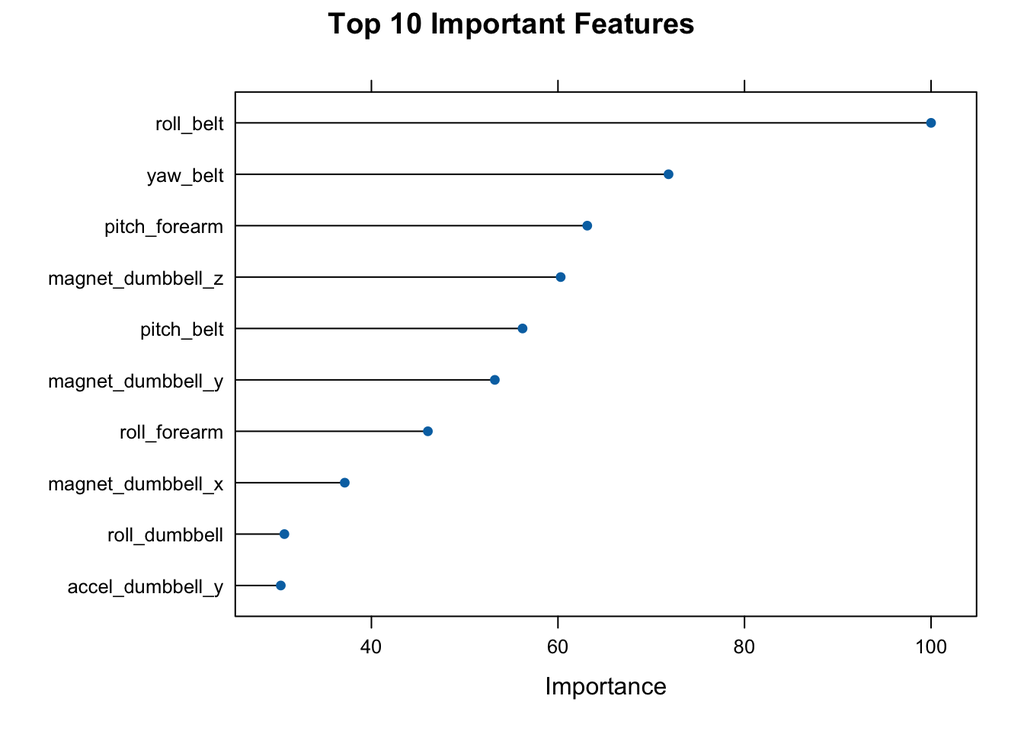

```r
# Feature importance
var_importance <- varImp(rf_model)
plot(var_importance, top = 10, main="Top 10 Important Features")
```

## Predictions on Test Set

```r
# Predict on test set
test_pred <- predict(rf_model, testing)

# Display predictions
test_pred
```

```
##  [1] B A B A A E D B A A B C B A E E A B B B
## Levels: A B C D E
```